# Taller Grupal II - Análisis Exploratorio de Datos, Universidad ICESI

### Reason

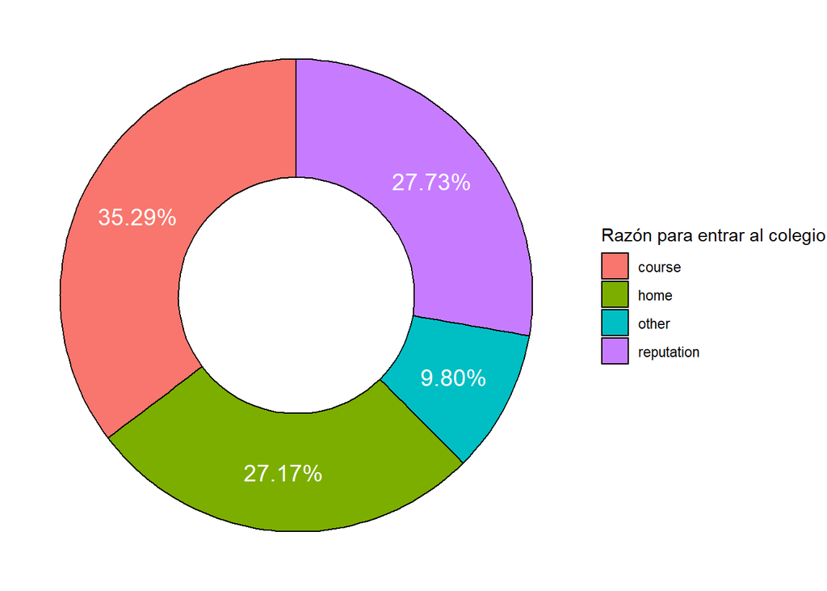

```r
TABLA_REASON=tabla_freq(base_f$reason,0)
#FRECUENCIA ABSOLUTA
ggplot(TABLA_REASON, aes(x=2, y=`Freq. Rel.`, fill=Categoría)) +
  geom_bar(stat="identity", width=1, color="black") +
  coord_polar("y", start=0)+
  labs(fill="Razón para entrar al colegio")+
  theme_void()+
  geom_text(aes(label = percent(`Freq. Rel.`)),position = position_stack(vjust = 0.5),color = "white", size=5)+
  xlim(0.5, 2.5)
```

La mayoría de estudiantes entraron al colegio por los cursos que veían en este y la minoría entraron por otra razón.

### TravelTime

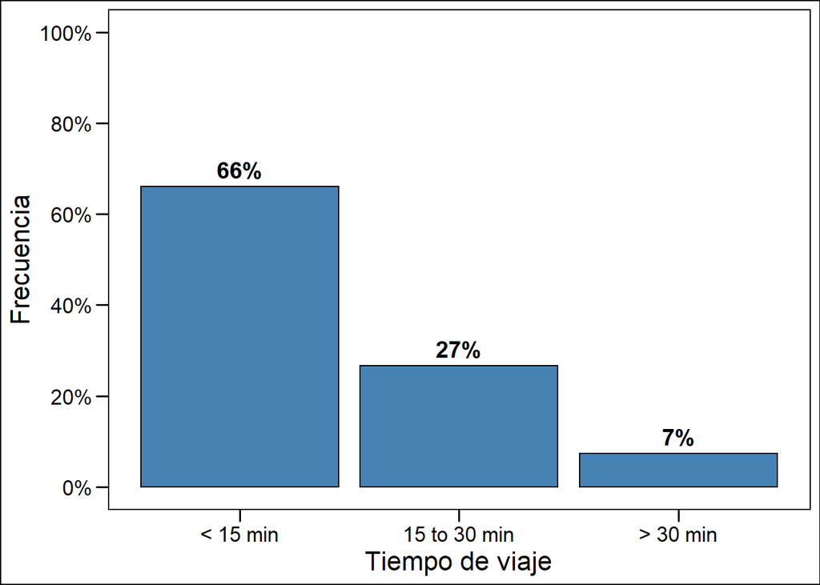

```r
TABLA_TRAVELTIME=tabla_freq(base_f$traveltime,0)
#FRECUENCIA ABSOLUTA
ggplot(TABLA_TRAVELTIME, aes(x=Categoría, y=`Freq. Rel.`))+
  geom_bar(stat = "identity", fill="steelblue", color="black")+
  labs(x="Tiempo de viaje",y="Frecuencia")+
  scale_y_continuous(limits = c(0,1), breaks = seq(0,1,0.2), labels = percent)+
  geom_text(aes(x=Categoría, y=`Freq. Rel.`, label=percent(`Freq. Rel.`)),vjust=-0.5, fontface = "bold", size=5)+
  theme_base()
```

### Paid

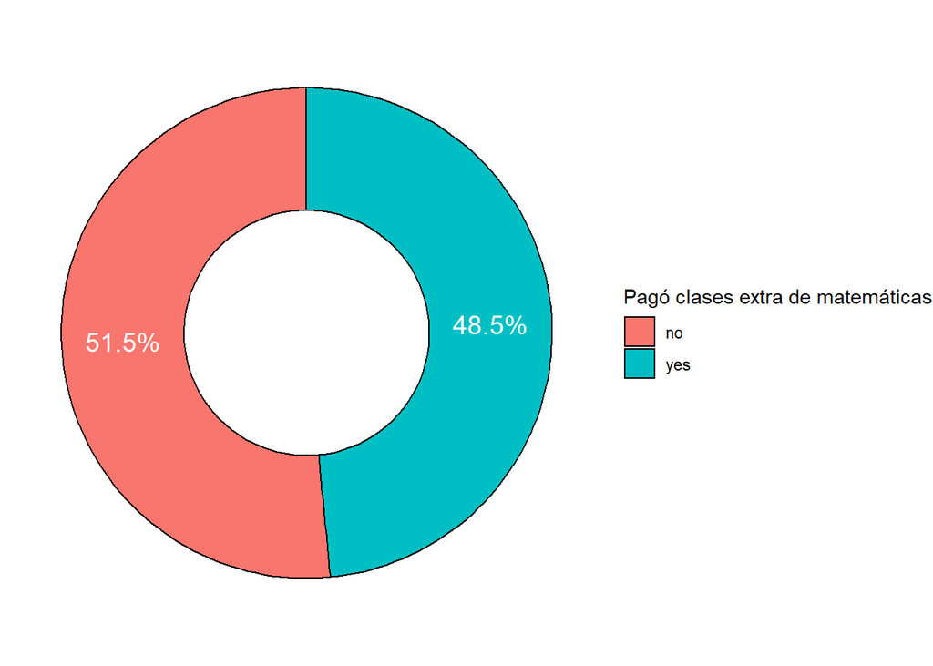

```r
TABLA_PAID=tabla_freq(base_f$paid,0)
#FRECUENCIA ABSOLUTA
ggplot(TABLA_PAID, aes(x=2, y=`Freq. Rel.`, fill=Categoría)) +
  geom_bar(stat="identity", width=1, color="black") +
  coord_polar("y", start=0)+
  labs(fill="Pagó clases extra de matemáticas")+
  theme_void()+
  geom_text(aes(label = percent(`Freq. Rel.`)),position = position_stack(vjust = 0.5),color = "white", size=5)+
  xlim(0.5, 2.5)
```

La proporción de los estudiantes que pagaron clases extra y los que no es muy equitativa, sin embargo, predominan los estudiantes que no las pagaron.

### Internet

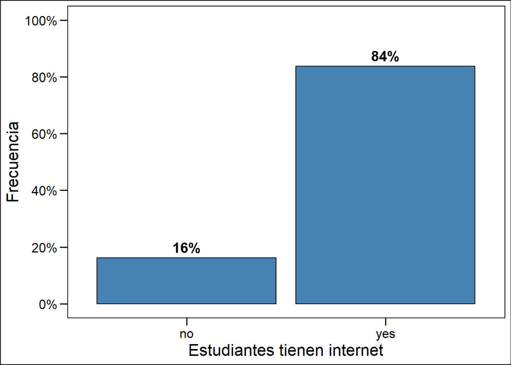

```r
TABLA_INTERNET=tabla_freq(base_f$internet,0)
#FRECUENCIA ABSOLUTA
ggplot(TABLA_INTERNET, aes(x=Categoría, y=`Freq. Rel.`))+
  geom_bar(stat = "identity", fill="steelblue", color="black")+
  labs(x="Estudiantes tienen internet",y="Frecuencia")+
  scale_y_continuous(limits = c(0,1), breaks = seq(0,1,0.2), labels = percent)+
  geom_text(aes(x=Categoría, y=`Freq. Rel.`, label=percent(`Freq. Rel.`)),vjust=-0.5, fontface = "bold", size=5)+
  theme_base()
```

La gran mayoría de estudiantes cuentan con internet en casa.

### Absences

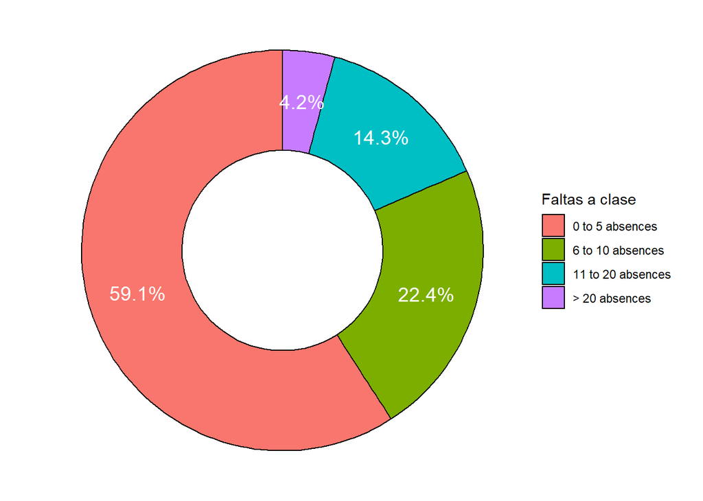

```r
TABLA_ABSENCES=tabla_freq(base_f$absences,0)
#FRECUENCIA ABSOLUTA
ggplot(TABLA_ABSENCES, aes(x=2, y=`Freq. Rel.`, fill=Categoría)) +
  geom_bar(stat="identity", width=1, color="black") +
  coord_polar("y", start=0)+
  labs(fill="Faltas a clase")+
  theme_void()+
  geom_text(aes(label = percent(`Freq. Rel.`)),position = position_stack(vjust = 0.5),color = "white", size=5)+
  xlim(0.5, 2.5)
```

La mayoría de los estudiantes tuvieron entre 0 y 5 ausencias, por otra parte, la minoría de los esutiantes tuvieron más de 20 ausencias.

## Análisis bivariado

### G3 vs Sexo

```r
descriptivas2(base_f$G3, base_f$sex)
```

```
##   Categoría Obs Mínimo 1er Q Mediana    Media 3er Q Máximo Desv Est Asimetría
## 1         F 185      4     9      11 11.20541    13     19 3.174452 0.1902339
## 2         M 172      5    10      12 11.86628    14     20 3.258748 0.2133468
##     Curtosis
## 1 -0.4009422
## 2 -0.5179835
```

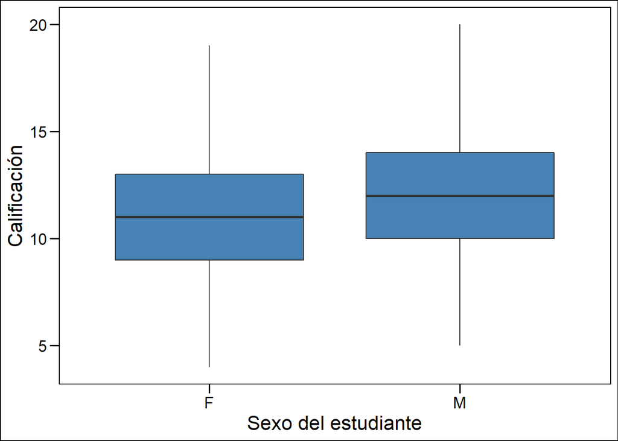

```r
ggplot(base_f, aes(x=sex, y=G3))+
    geom_boxplot(fill="steelblue")+
    labs(x="Sexo del estudiante",y="Calificación")+
    theme_base()
```

Se puede decir que los hombres obtienen una calificación más alta que las mujeres.

### G3 vs Age

```r
descriptivas2(base_f$G3, base_f$age2)
```

```
##   Categoría Obs Mínimo 1er Q Mediana    Media 3er Q Máximo Desv Est  Asimetría
## 1        15  76      5    10    12.0 12.14474    15     19 3.447526 0.07183741
## 2        16  97      5    10    11.0 11.82474    14     20 3.188555 0.06636565
## 3        17  90      4     9    11.0 11.18889    13     18 3.118969 0.05265289
## 4  18 o más  94      5     9    10.5 11.03191    13     19 3.119319 0.55111703
##     Curtosis
## 1 -0.6658607
## 2 -0.4665680
## 3 -0.3949846
## 4 -0.1896567
```

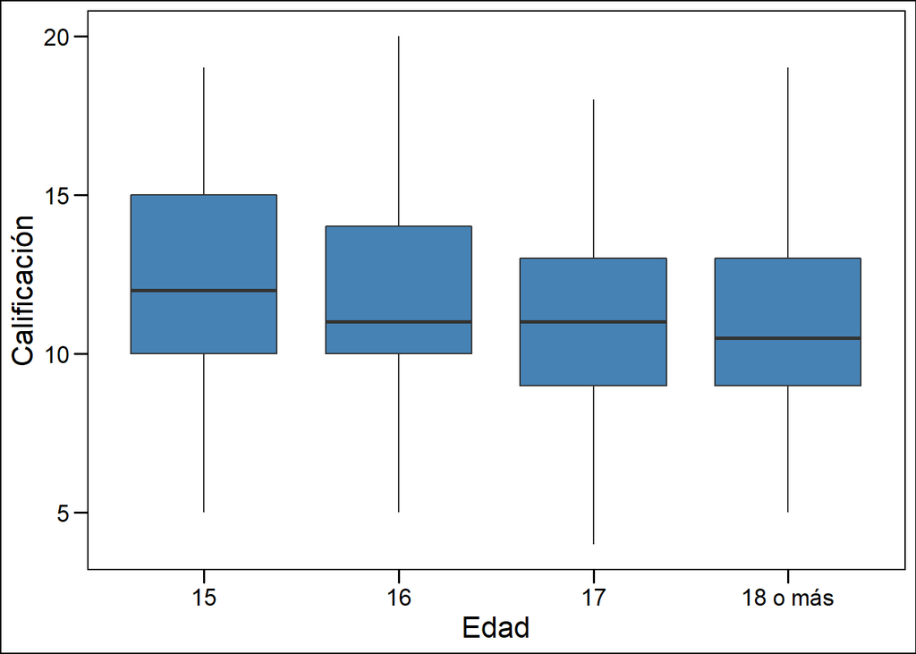

```r
ggplot(base_f, aes(x=age2, y=G3))+
    geom_boxplot(fill="steelblue")+
    labs(x="Edad",y="Calificación")+
    theme_base()
```

Podemos decir que los estudiantes que tienen 15 años sacan mejores calificaciones, además, después siguen los estudiantes que tienen 16 años debido a su mejor desempeño en el tercer cuartil, por último, los estudiantes que tienen 18 o más años, por la mediana, se deduce que sacan menores calificaciones.

### G3 vs Medu

```r
descriptivas2(base_f$G3, base_f$Medu)
```

```
##                   Categoría Obs Mínimo 1er Q Mediana    Media 3er Q Máximo
## 1 None or primary education  53      5     9      10 10.39623 12.00     16
## 2          5th to 9th grade  89      6    10      11 11.25843 13.00     19
## 3      secondary education   90      5     9      11 11.33333 13.75     19
## 4          higher education 125      4    10      13 12.32800 15.00     20
##   Desv Est   Asimetría    Curtosis
## 1 2.596889  0.13882743 -0.24563020
## 2 2.736654  0.33030475 -0.05892119
## 3 3.424958  0.26955529 -0.59938963
## 4 3.475202 -0.09664056 -0.63600011
```

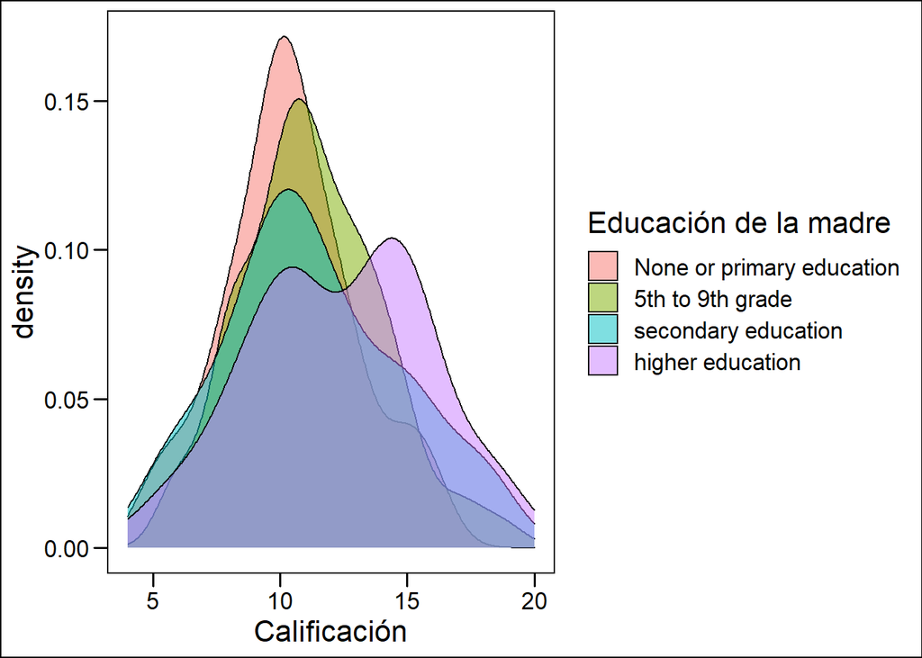

```r
ggplot(base_f, aes(x=G3, fill=Medu))+
    geom_density(alpha=0.5)+
    labs(x="Calificación", fill="Educación de la madre")+
    theme_base()
```

Apartir de la gráfica, se puede decir que a mayor educación de la madre, mejores serán las calificaciones de los hijos.